# Explore_bikeshare_data

### Explore Bike Share Data

For this project, your goal is to ask and answer three questions about the available bikeshare data from Washington, Chicago, and New York. This notebook can be submitted directly through the workspace when you are confident in your results.

You will be graded against the project [Rubric](https://review.udacity.com/#!/rubrics/2508/view) by a mentor after you have submitted. To get you started, you can use the template below, but feel free to be creative in your solutions!

```r
ny = read.csv('new_york_city.csv')
wash = read.csv('washington.csv')
chi = read.csv('chicago.csv')
```

```r
head(ny)
```

| X | Start.Time | End.Time | Trip.Duration | Start.Station | End.Station | User.Type | Gender | Birth.Year |
| --- | --- | --- | --- | --- | --- | --- | --- | --- |
| 5688089 | 2017-06-11 14:55:05 | 2017-06-11 15:08:21 | 795 | Suffolk St & Stanton St | W Broadway & Spring St | Subscriber | Male | 1998 |
| 4096714 | 2017-05-11 15:30:11 | 2017-05-11 15:41:43 | 692 | Lexington Ave & E 63 St | 1 Ave & E 78 St | Subscriber | Male | 1981 |
| 2173887 | 2017-03-29 13:26:26 | 2017-03-29 13:48:31 | 1325 | 1 Pl & Clinton St | Henry St & Degraw St | Subscriber | Male | 1987 |
| 3945638 | 2017-05-08 19:47:18 | 2017-05-08 19:59:01 | 703 | Barrow St & Hudson St | W 20 St & 8 Ave | Subscriber | Female | 1986 |
| 6208972 | 2017-06-21 07:49:16 | 2017-06-21 07:54:46 | 329 | 1 Ave & E 44 St | E 53 St & 3 Ave | Subscriber | Male | 1992 |
| 1285652 | 2017-02-22 18:55:24 | 2017-02-22 19:12:03 | 998 | State St & Smith St | Bond St & Fulton St | Subscriber | Male | 1986 |

```r
head(wash)
```

| X | Start.Time | End.Time | Trip.Duration | Start.Station | End.Station | User.Type |
| --- | --- | --- | --- | --- | --- | --- |
| 1621326 | 2017-06-21 08:36:34 | 2017-06-21 08:44:43 | 489.066 | 14th & Belmont St NW | 15th & K St NW | Subscriber |
| 482740 | 2017-03-11 10:40:00 | 2017-03-11 10:46:00 | 402.549 | Yuma St & Tenley Circle NW | Connecticut Ave & Yuma St NW | Subscriber |
| 1330037 | 2017-05-30 01:02:59 | 2017-05-30 01:13:37 | 637.251 | 17th St & Massachusetts Ave NW | 5th & K St NW | Subscriber |
| 665458 | 2017-04-02 07:48:35 | 2017-04-02 08:19:03 | 1827.341 | Constitution Ave & 2nd St NW/DOL | M St & Pennsylvania Ave NW | Customer |
| 1481135 | 2017-06-10 08:36:28 | 2017-06-10 09:02:17 | 1549.427 | Henry Bacon Dr & Lincoln Memorial Circle NW | Maine Ave & 7th St SW | Subscriber |
| 1148202 | 2017-05-14 07:18:18 | 2017-05-14 07:24:56 | 398.000 | 1st & K St SE | Eastern Market Metro / Pennsylvania Ave & 7th St SE | Subscriber |

```r
head(chi)
```

| X | Start.Time | End.Time | Trip.Duration | Start.Station | End.Station | User.Type | Gender | Birth.Year |
| --- | --- | --- | --- | --- | --- | --- | --- | --- |
| 1423854 | 2017-06-23 15:09:32 | 2017-06-23 15:14:53 | 321 | Wood St & Hubbard St | Damen Ave & Chicago Ave | Subscriber | Male | 1992 |
| 955915 | 2017-05-25 18:19:03 | 2017-05-25 18:45:53 | 1610 | Theater on the Lake | Sheffield Ave & Waveland Ave | Subscriber | Female | 1992 |
| 9031 | 2017-01-04 08:27:49 | 2017-01-04 08:34:45 | 416 | May St & Taylor St | Wood St & Taylor St | Subscriber | Male | 1981 |
| 304487 | 2017-03-06 13:49:38 | 2017-03-06 13:55:28 | 350 | Christiana Ave & Lawrence Ave | St. Louis Ave & Balmoral Ave | Subscriber | Male | 1986 |
| 45207 | 2017-01-17 14:53:07 | 2017-01-17 15:02:01 | 534 | Clark St & Randolph St | Desplaines St & Jackson Blvd | Subscriber | Male | 1975 |
| 1473887 | 2017-06-26 09:01:20 | 2017-06-26 09:11:06 | 586 | Clinton St & Washington Blvd | Canal St & Taylor St | Subscriber | Male | 1990 |

### Question 1

**whose user that rents the bike more during the months ?**

[output not shown]

```
Adolescence         Adult Senior Adult
        3328         1754         1801
```

```
Adolescence         Adult Senior Adult
       10721        13080        25751
```

1. '06'

2. '05'

3. '01'

4. '03'

5. '04'

6. '02'

```
             Customer Subscriber
         1       1746       6883
```

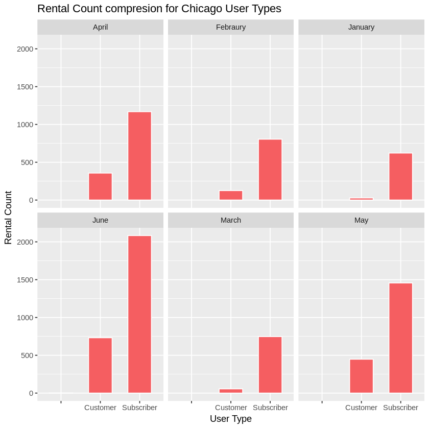

```
             Customer Subscriber
         0       5558      49093
```

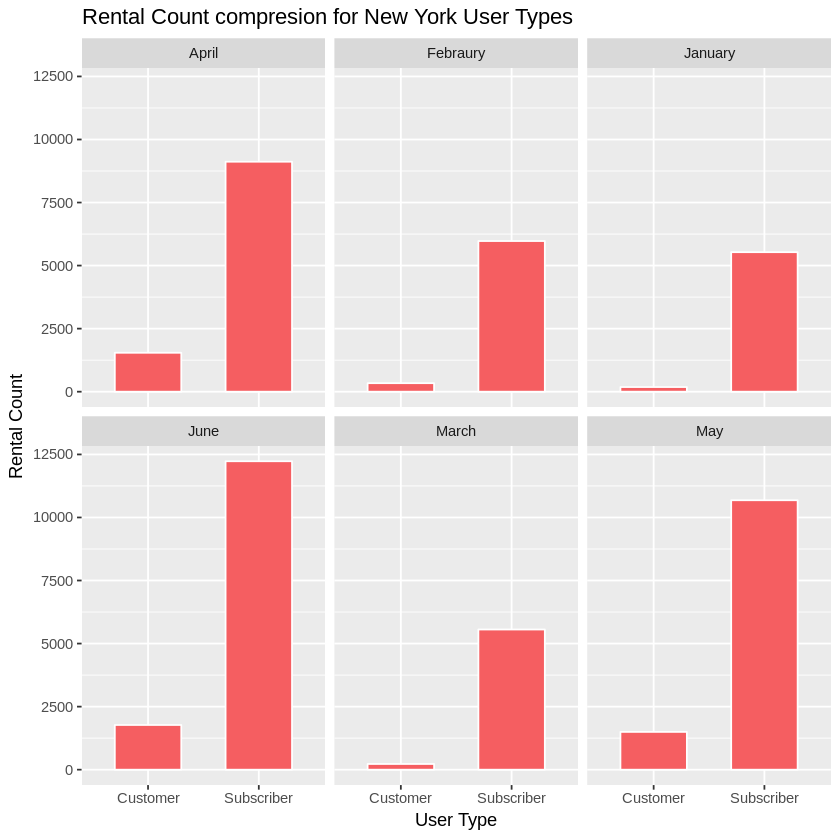

```
             Customer Subscriber
         1      23450      65600
```

```
             Customer Subscriber
         1       1746       6883
```

```
             Customer Subscriber
         0       5558      49093
```

```
             Customer Subscriber
         1      23450      65600
```

**null device:** 1

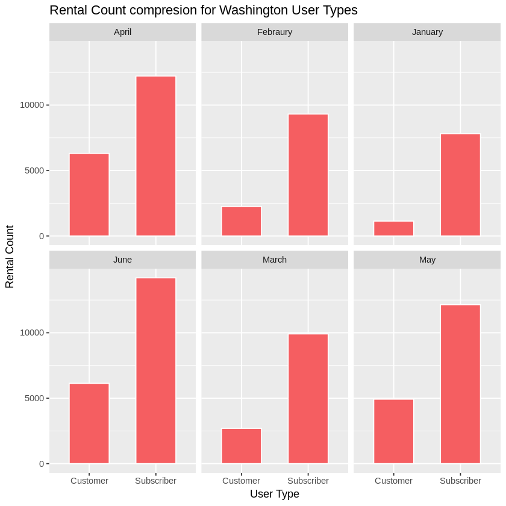

```r
# Your solution code goes here
#loading libraries
library(dplyr)
library(plyr)
library(ggplot2)
##preprocessing for dataset

#a# .. replacing blank cell in Gender with NA .. #a#
chi$Gender[chi$Gender == ""] <- '0'
ny$Gender[ny$Gender == ""] <- '0'
## .. replace blank space in user.type .. #
ny$User.Type[ny$User.Type == ""] <- '0'


#b#making Age.Class as anew_col for classify the Birth.Year as 3 levels (senior adult ,adult ,adulescence)#b#
Age.Class <- ifelse(
    chi$Birth.Year >= 1899 & chi$Birth.Year <= 1975,
    chi['Age.Class'] <- 'Senior Adult',
    ifelse(
        chi$Birth.Year > 1975 & chi$Birth.Year <= 1984,
        chi['Age.Class'] <- 'Adult',
        ifelse(
            chi$Birth.Year > 1984 & chi$Birth.Year <= 2016,
            chi['Age.Class'] <- 'Adolescence ',
            chi['Age.Class'] <- '0'
        )
    )
)
chi['Age.Class'] <- Age.Class
table(chi$Age.Class)

#c## .. for ny data set .. #c#
Age.Class <- ifelse(
    ny$Birth.Year >= 1885 & ny$Birth.Year <= 1981,
    ny['Age.Class'] <- 'Senior Adult',
    ifelse(
        ny$Birth.Year > 1981 & ny$Birth.Year <= 1988,
        ny['Age.Class'] <- 'Adult',
        ifelse(
            ny$Birth.Year > 1988 & ny$Birth.Year <= 2001,
            ny['Age.Class'] <- 'Adolescence ',
            ny['Age.Class'] <- '0'
        )
    )
)
ny['Age.Class'] <- Age.Class
table(ny$Age.Class)


#d# .. splitting the hour .. #d#
hour <- function(data) {
    start_time <-
        sapply(strsplit(as.character(data$Start.Time), " "), "[", 2)
    ##suset hour from the data
    hour <- substr(x = start_time, 1, 2)
}
##calling fun hour for chi dataset
hour_chi <- hour(chi)
chi['hour'] <- hour_chi
##calling fun hour for chi dataset
hour_ny <- hour(ny)
ny['hour'] <- hour_ny
##calling fun hour for wash dataset
hour_wash <- hour(wash)
wash['hour'] <- hour_wash


#e# .. split the date .. #e#
month <- function(data) {
    start_date <-
        sapply(strsplit(as.character(data$Start.Time), " "), "[", 1)
    ##subset month from the data
    month <- substr(x = start_date, 6, 7)
}
##calling fun with data = chi
month_chi <- month(chi)
chi['month'] <- month_chi
unique(chi$month)
##calling function with data = ny
month_ny <- month(ny)
ny['month'] <- month_ny
##calling function with data = wash
month_wash <- month(wash)
wash['month'] <- month_wash


##replacing '01' with 'january' and '02' with 'February' and so on ...
old <- c('01', '02', '03', '04', '05', '06')
new <- c('January', 'Febraury', 'March', 'April', 'May', 'June')
chi$month[chi$month %in% old] <-
    new[match(chi$month, old, nomatch = 0)]
ny$month[ny$month %in% old] <-
    new[match(ny$month, old, nomatch = 0)]
wash$month[wash$month %in% old] <-
    new[match(wash$month, old, nomatch = 0)]




#solution for question 1
##visualization

rental_user <- function(data,title) {
    ggplot(data = data,
           aes(x = User.Type)) +
        labs(title = title,
             x = 'User Type',
             y = 'Rental Count'
             ) +
        geom_histogram(
            aes(y = ..count..),
            stat = "count",
            width = .6,
            col = "white",
            fill = "#f55e61"
        ) +
        facet_wrap( ~ data$month)
}
## for chi df ,Subscriber rents bike more than Customer and independent.
rental_user(chi,title="Rental Count compresion for Chicago User Types")
table(chi$User.Type)

## for ny df ,Subscriber rents bike more than Customer and independent.
rental_user(subset(ny,!is.na(User.Type)),title ="Rental Count compresion for New York User Types" )
table(ny$User.Type)

## for wash df,Subscriber rents bike more than Customer and it is clearly shown that there is a growth in the rental during last month June.
rental_user(na.omit(wash),title="Rental Count compresion for Washington User Types")
table(wash$User.Type)

##updating the code with the summary statistics in the 2nd line of the code
##Summary Statistics:
#To calculate the rentals per user type of all the cities from the dataset
#ressources : https://www.tutorialspoint.com/r/r_data_frames.htm
#Chicago
table(chi$User.Type)
#New York
table(ny$User.Type)
#Washington
table(wash$User.Type)

dev.off()
```

```r
##updating the code with the summary statistics in the 2nd line of the code
##Summary Statistics:
#To calculate the rentals per user type of all the cities from the dataset
#ressources : https://www.tutorialspoint.com/r/r_data_frames.htm
#Chicago
table(chi$User.Type)
#New York
table(ny$User.Type)
#Washington
table(wash$User.Type)
```

```
             Customer Subscriber
         1       1746       6883
```

```
             Customer Subscriber
         0       5558      49093
```

```
             Customer Subscriber
         1      23450      65600
```

**We used the table() funtion on each of the database and as from the result we can find that for Chicago-"Subscriber" rents bike more than "Customer" by a difference of 5137. Similarly for New York-"Subscriber" rents bike more than "Customer" by a difference of 43,535. And for Washington also we can see that "Subscriber" rents bike more than "Customer" by a difference of 42,150 and it is clearly shown that there is a growth in the rental base by the subscriber side during last month June.**

### Question 2

**which Hour does it has most used of the bike riding ?**

```
  00   01   02   03   04   05   06   07   08   09   10   11   12   13   14   15
  55   26   18   16   17   67  243  560  693  385  320  467  482  530  466  599
  16   17   18   19   20   21   22   23
 804 1039  679  435  268  237  146   78
```

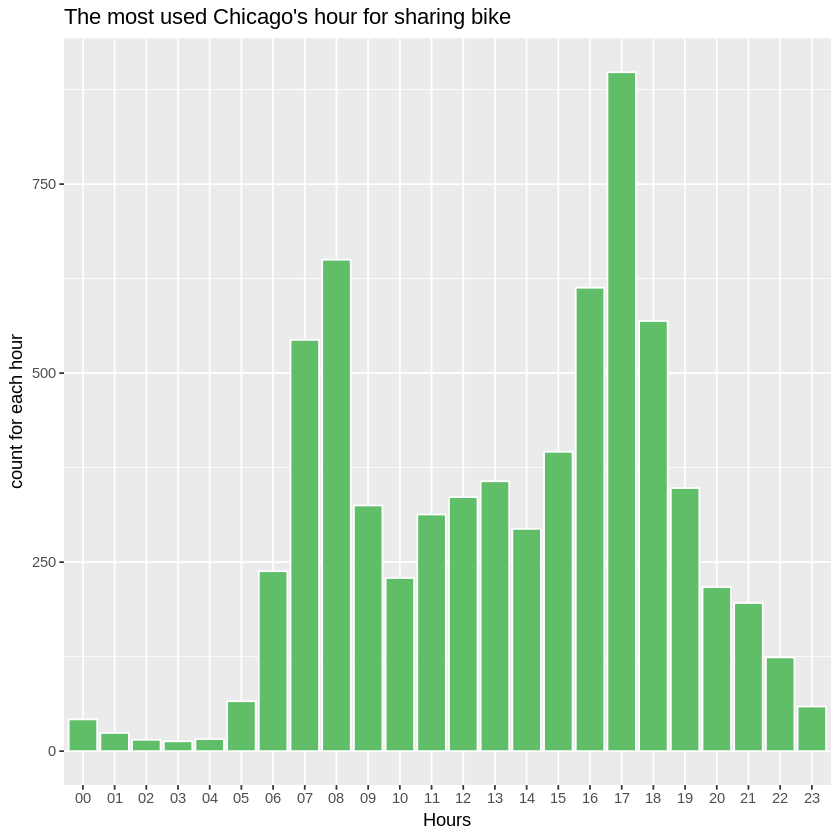

```
  00   01   02   03   04   05   06   07   08   09   10   11   12   13   14   15
 436  231  152   60   84  312 1212 2512 4337 3521 2471 2643 2866 3054 3157 3356
  16   17   18   19   20   21   22   23
3894 5503 5281 3594 2437 1646 1214  797
```

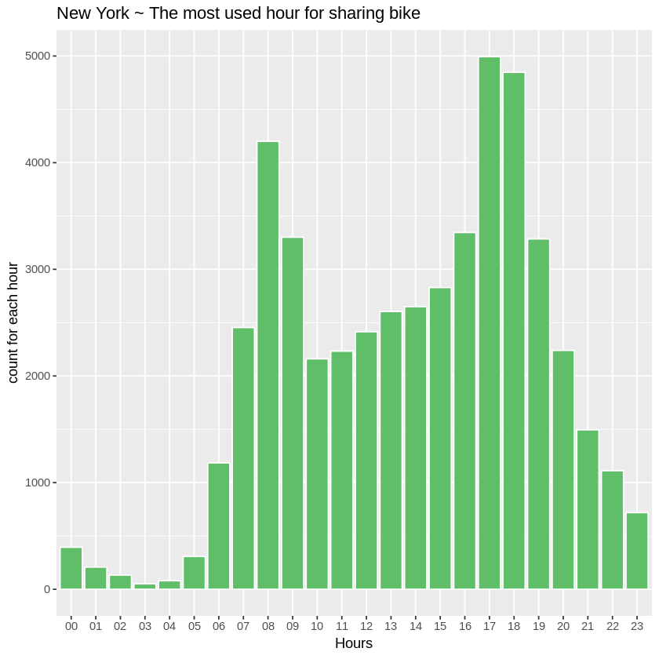

```
  00   01   02   03   04   05   06   07   08   09   10   11   12   13   14   15
 227 3500 3421 3655 4541 6741 6994 8490 9805 5957 4788 5057 5569 1906 1774 2136
  16   17   18   19   20   21   22   23
2746 3958 3028 1772 1181  855  605  344
```

```
  00   01   02   03   04   05   06   07   08   09   10   11   12   13   14   15
  55   26   18   16   17   67  243  560  693  385  320  467  482  530  466  599
  16   17   18   19   20   21   22   23
 804 1039  679  435  268  237  146   78
```

```
  00   01   02   03   04   05   06   07   08   09   10   11   12   13   14   15
 436  231  152   60   84  312 1212 2512 4337 3521 2471 2643 2866 3054 3157 3356
  16   17   18   19   20   21   22   23
3894 5503 5281 3594 2437 1646 1214  797
```

```
  00   01   02   03   04   05   06   07   08   09   10   11   12   13   14   15
 227 3500 3421 3655 4541 6741 6994 8490 9805 5957 4788 5057 5569 1906 1774 2136
  16   17   18   19   20   21   22   23
2746 3958 3028 1772 1181  855  605  344
```

**null device:** 1

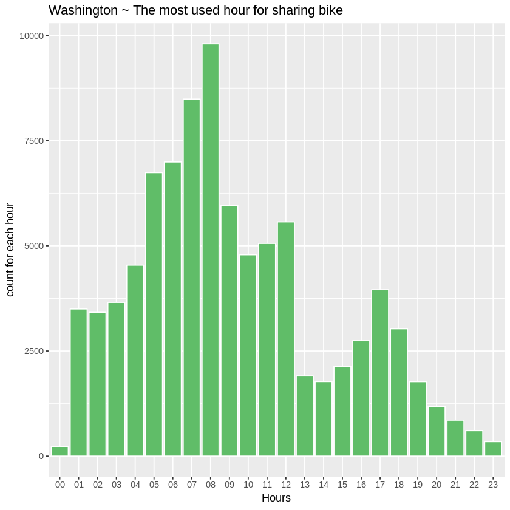

```r
# Your solution code goes here
hours_ride <- function(data,title) {
    qplot(
        x = data$hour,
        data = data,
        xlab = "Hours",
        ylab = "count for each hour",
        main = title,
        color = I('white'),
        fill = I('#60BD68')
    )
}
## for chi dataset, The most used hour for bicycle borrowing was at 5 pm, followed by 4 pm and then from the plotting: ##
hours_ride(data = na.omit(chi),title="The most used Chicago's hour for sharing bike")
table(chi$hour)

## for ny dataset ,The most used hour for bicycle borrowing was at 5 pm, followed by 6 pm##
hours_ride(data = na.omit(ny),title="New York ~ The most used hour for sharing bike")
table(ny$hour)

## from the washington plot ,The most used hour for bicycle borrowing was at 8 AM, followed by 7 AM as we can plot: ##
hours_ride(data = na.omit(wash),title="Washington ~ The most used hour for sharing bike")
table(wash$hour)

##updating the code with the summary statistics in the 2nd line of the code
##Summary Statistics:
#To calculate the hour during which bikes were mostly used from the dataset
#ressources : https://www.tutorialspoint.com/r/r_data_frames.htm
#Chicago
table(chi$hour)
#New York
table(ny$hour)
#Washington
table(wash$hour)





dev.off()
```

```r
##updating the code with the summary statistics in the 2nd line of the code
##Summary Statistics:
#To calculate the hour during which bikes were mostly used from the dataset
#ressources : https://www.tutorialspoint.com/r/r_data_frames.htm
#Chicago
table(chi$hour)
#New York
table(ny$hour)
#Washington
table(wash$hour)
```

```
  00   01   02   03   04   05   06   07   08   09   10   11   12   13   14   15
  55   26   18   16   17   67  243  560  693  385  320  467  482  530  466  599
  16   17   18   19   20   21   22   23
 804 1039  679  435  268  237  146   78
```

```
  00   01   02   03   04   05   06   07   08   09   10   11   12   13   14   15
 436  231  152   60   84  312 1212 2512 4337 3521 2471 2643 2866 3054 3157 3356
  16   17   18   19   20   21   22   23
3894 5503 5281 3594 2437 1646 1214  797
```

```
  00   01   02   03   04   05   06   07   08   09   10   11   12   13   14   15
 227 3500 3421 3655 4541 6741 6994 8490 9805 5957 4788 5057 5569 1906 1774 2136
  16   17   18   19   20   21   22   23
2746 3958 3028 1772 1181  855  605  344
```

**We used the table() funtion on each of the database and as from the result we can find that for Chicago For Chicago-The most used hour for bicycle borrowing was at 5 pm with 1039 bookings,followed by 4 pm with 804 bookings. Similarly for New York-The most used hour for bicycle borrowing was at 5 pm with 5503 bookings,followed by 6 pm with 5281 bookings. And for Washington-The most used hour for bicycle borrowing was at 8 AM with 9805 bookings,followed by 7 AM with 8490 bookings. So we can conclude that evening schedule around 4pm-6pm is good around Chicago and New York while the morning circle is for Washington.**